# Survival Analysis

# Introduction

This assignment focuses on conducting survival analysis on the Echocardiogram2 dataset using R. Survival analysis is a statistical method widely used in medical and biological research to analyze time-to-event data, such as the time until a patient experiences an event of interest or until the end of a study period. In this assignment, we aim to explore the dataset, preprocess the data, and perform survival analysis to answer specific questions related to the probability of survival over time for individuals in different treatment groups.

#### Objectives

**Data Exploration and Preprocessing:** The assignment begins with loading the required R packages and exploring the Echocardiogram2 dataset. This involves examining the structure of the data, checking for missing values, and handling any preprocessing steps deemed necessary.

**Correlation Analysis:** A correlation analysis is performed to understand the relationships between numeric variables in the dataset. The results are visualized using correlation matrices.

**Survival Analysis Setup:** The dataset includes variables representing survival time and event status. The survival package in R is utilized to create a Surv object and analyze the data using Kaplan-Meier survival curves.

**Stratified Kaplan-Meier Curves:** To further investigate the impact of different treatment groups on survival, Kaplan-Meier curves are generated with stratification by group. The strata are visualized, and overall survival curves are plotted.

**Log-Rank Test:** The log-rank test, a common statistical test in survival analysis, is performed to assess the difference in survival curves between treatment groups. The results are presented along with visualizations of Kaplan-Meier curves incorporating log-rank test information.

##### Load and Explore the Dataset(echocardiogram2)

```r
dataset_path <- "C:\\Zakir\\assignment\\echocardiogram2.csv"
echocardiogram2_data <- read.csv(dataset_path)
```

##### Explore the data

```r
str(echocardiogram2_data)
```

```
## 'data.frame':    133 obs. of  13 variables:
##  $ survival            : num  11 19 16 57 19 26 13 50 19 25 ...
##  $ alive               : int  0 0 0 0 1 0 0 0 0 0 ...
##  $ age                 : num  71 72 55 60 57 68 62 60 46 54 ...
##  $ pericardialeffusion : int  0 0 0 0 0 0 0 0 0 0 ...
##  $ fractionalshortening: num  0.26 0.38 0.26 0.253 0.16 0.26 0.23 0.33 0.34 0.14 ...
##  $ epss                : num  9 6 4 12.1 22 ...
##  $ lvdd                : num  4.6 4.1 3.42 4.6 5.75 ...
##  $ wallmotion.score    : num  14 14 14 16 18 12 22.5 14 16 15.5 ...
##  $ wallmotion.index    : num  1 1.7 1 1.45 2.25 ...
##  $ mult                : num  1 0.588 1 0.788 0.571 ...
##  $ name                : chr  "name" "name" "name" "name" ...
##  $ group               : chr  "1" "1" "1" "1" ...
##  $ aliveat1            : int  0 0 0 0 0 0 0 0 0 0 ...
```

##### Summary

```r
summary(echocardiogram2_data)
```

```
##     survival          alive             age        pericardialeffusion
##  Min.   : 0.030   Min.   :0.0000   Min.   :35.00   Min.   : 0.0000
##  1st Qu.: 7.875   1st Qu.:0.0000   1st Qu.:57.00   1st Qu.: 0.0000
##  Median :23.500   Median :0.0000   Median :62.00   Median : 0.0000
##  Mean   :22.183   Mean   :0.3282   Mean   :62.81   Mean   : 0.7651
##  3rd Qu.:33.000   3rd Qu.:1.0000   3rd Qu.:67.75   3rd Qu.: 0.0000
##  Max.   :57.000   Max.   :1.0000   Max.   :86.00   Max.   :77.0000
##  NA's   :3        NA's   :2        NA's   :7       NA's   :1
##  fractionalshortening      epss            lvdd       wallmotion.score
##  Min.   :0.0100       Min.   : 0.00   Min.   :2.320   Min.   : 2.00
##  1st Qu.:0.1500       1st Qu.: 7.00   1st Qu.:4.230   1st Qu.:11.00
##  Median :0.2050       Median :11.00   Median :4.650   Median :14.00
##  Mean   :0.2167       Mean   :12.16   Mean   :4.763   Mean   :14.44
##  3rd Qu.:0.2700       3rd Qu.:16.10   3rd Qu.:5.300   3rd Qu.:16.50
##  Max.   :0.6100       Max.   :40.00   Max.   :6.780   Max.   :39.00
##  NA's   :9            NA's   :16      NA's   :12      NA's   :5
##  wallmotion.index      mult            name              group
##  Min.   :1.000    Min.   :0.1400   Length:133         Length:133
##  1st Qu.:1.000    1st Qu.:0.7140   Class :character   Class :character
##  Median :1.216    Median :0.7860   Mode  :character   Mode  :character
##  Mean   :1.378    Mean   :0.7862
##  3rd Qu.:1.508    3rd Qu.:0.8570
##  Max.   :3.000    Max.   :2.0000
##  NA's   :3        NA's   :4
##     aliveat1
##  Min.   :0.0000
##  1st Qu.:0.0000
##  Median :0.0000
##  Mean   :0.3467
##  3rd Qu.:1.0000
##  Max.   :2.0000
##  NA's   :58
```

##### Select numeric columns

```r
numeric_columns <- sapply(echocardiogram2_data, is.numeric)
```

##### Check for missing values

```r
missing_values <- colSums(is.na(echocardiogram2_data))
```

##### Display missing values

```r
print("Missing Values:")
```

```
## [1] "Missing Values:"
```

```r
print(missing_values)
```

```
##             survival                alive                  age
##                    3                    2                    7
##  pericardialeffusion fractionalshortening                 epss
##                    1                    9                   16
##                 lvdd     wallmotion.score     wallmotion.index
##                   12                    5                    3
##                 mult                 name                group
##                    4                    1                   22
##             aliveat1
##                   58
```

##### Replace missing values with 0 (or any other appropriate method)

```r
echocardiogram2_data[is.na(echocardiogram2_data)] <- 0
```

##### Perform correlation analysis

```r
correlation_matrix <- cor(echocardiogram2_data[, numeric_columns, drop = FALSE])
```

##### Visualize the correlation matrix

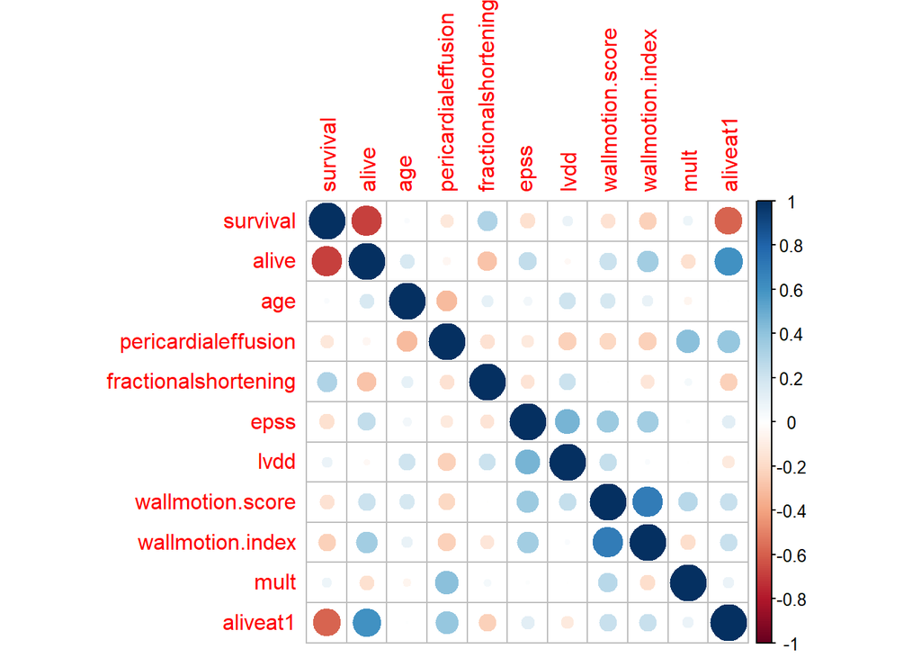

```r
corrplot::corrplot(correlation_matrix)
```

##### Load the necessary packages

```r
library(knitr)
```

##### Use kable() to visualize the data

```r
kable(head(echocardiogram2_data))
```

| survival | alive | age | pericardialeffusion | fractionalshortening | epss | lvdd | wallmotion.score | wallmotion.index | mult | name | group | aliveat1 |
| --- | --- | --- | --- | --- | --- | --- | --- | --- | --- | --- | --- | --- |
| 11 | 0 | 71 | 0 | 0.260 | 9.000 | 4.600 | 14 | 1.00 | 1.000 | name | 1 | 0 |
| 19 | 0 | 72 | 0 | 0.380 | 6.000 | 4.100 | 14 | 1.70 | 0.588 | name | 1 | 0 |
| 16 | 0 | 55 | 0 | 0.260 | 4.000 | 3.420 | 14 | 1.00 | 1.000 | name | 1 | 0 |
| 57 | 0 | 60 | 0 | 0.253 | 12.062 | 4.603 | 16 | 1.45 | 0.788 | name | 1 | 0 |
| 19 | 1 | 57 | 0 | 0.160 | 22.000 | 5.750 | 18 | 2.25 | 0.571 | name | 1 | 0 |
| 26 | 0 | 68 | 0 | 0.260 | 5.000 | 4.310 | 12 | 1.00 | 0.857 | name | 1 | 0 |

#### Explanation:

In conducting the Kaplan-Meier Estimator analysis in R, I executed the following steps:

##### Loading Necessary Libraries:

I began by loading essential libraries, including survival, tidyverse, devtools, and survminer. These libraries provide the required functions and tools for survival analysis and data visualization.

##### Building a Surv Object:

Using the Surv() function from the survival package, I created a Surv object (surv_object) that captures the survival time and event information from the echocardiogram2 dataset. This object serves as the basis for subsequent survival analyses.

##### Analyzing Data with survfit():

I utilized the survfit() function to analyze the survival data. The resulting survfit_object represents the Kaplan-Meier estimator, providing insights into the survival probability over time.

##### Displaying Summary of survfit Object:

A summary of the survfit_object was displayed, offering key statistical information about the Kaplan-Meier survival analysis.

##### Generating Kaplan-Meier Curve with Stratification:

To visualize the survival curve, I used the ggsurvplot() function. The Kaplan-Meier curve was stratified by the ‘group’ variable, enabling a more nuanced understanding of survival probabilities for different groups.

## Question:

#### “What is the probability of survival over time for individuals in different treatment groups in the echocardiogram2 dataset?”

##### Our dataset have a variable named ‘survival’ representing the time to event

##### and a variable named ‘alive’ representing the event status (1 for event, 0 for censored)

## Calculate the Kaplan-Meier Estimator in R

##### In this analysis, we will use the Kaplan-Meier estimator to assess the survival probability over time based on a given dataset. The survival analysis involves creating a Surv object, analyzing the data with the survfit() function, and generating a Kaplan-Meier curve using the ggsurvplot() function.

##### Load the survival package

```r
library(survival)
```

##### 1.Create a Surv object using the Surv() function (Build a Surv Object)

```r
surv_object <- Surv(time = echocardiogram2_data$survival, event = echocardiogram2_data$alive)
```

##### Print the Surv object

```r
print(surv_object)
```

```
##   [1] 11.00+ 19.00+ 16.00+ 57.00+ 19.00  26.00+ 13.00+ 50.00+ 19.00+ 25.00+
##  [11] 10.00  52.00+ 52.00+ 44.00+  0.50  24.00+  0.50   0.50  22.00   1.00
##  [21]  0.75   0.75   0.50   5.00  48.00+ 29.00+ 29.00+ 29.00+  0.25  36.00+
##  [31]  1.00   1.00   3.00  27.00+ 35.00+ 26.00+ 16.00+  1.00  19.00+ 31.00+
##  [41] 32.00+ 16.00+ 40.00+ 46.00+  2.00  37.00+ 19.50  20.00   0.25   0.00+
##  [51]  0.00+  2.00   7.00  10.00+ 12.00+  1.00  10.00+ 45.00+ 22.00+ 53.00+
##  [61] 38.00+ 26.00+  9.00+ 26.00+  0.50  12.00+ 49.00+  0.75  49.00+ 47.00+
##  [71] 41.00+  0.25  33.00+ 29.00+ 41.00+ 26.00+ 15.00+  0.25   0.03  12.00+
##  [81] 32.00+ 32.00+ 27.00+ 23.00+  0.75   0.75  34.00+  1.00  21.00  55.00+
##  [91] 15.00   0.50  35.00+ 53.00+ 33.00+  0.00  33.00+ 40.00  33.00+  5.00
## [101]  4.00  31.00+ 33.00+ 22.00+ 25.00+  1.25  24.00+ 25.00+ 24.00+  0.75
## [111]  3.00  27.00+ 13.00+ 36.00+ 25.00+ 27.00+ 34.00+ 37.00+ 34.00+ 28.00
## [121] 28.00+ 17.00+ 38.00+ 31.00+ 12.00+ 36.00+ 17.00+ 21.00+  7.50  41.00+
## [131] 36.00+ 22.00+ 20.00+
```

##### 2. Analyze the data with survfit() _ Analyze Data with survfit()

```r
survfit_object <- survfit(surv_object ~ 1)  # ~1 assumes a single group, adjust if needed
```

##### Display summary of the survfit object

```r
summary(survfit_object)
```

```
## Call: survfit(formula = surv_object ~ 1)
##
##   time n.risk n.event survival std.err lower 95% CI upper 95% CI
##   0.00    133       1    0.992 0.00749        0.978        1.000
##   0.03    130       1    0.985 0.01063        0.964        1.000
##   0.25    129       4    0.954 0.01822        0.919        0.991
##   0.50    125       6    0.909 0.02518        0.860        0.959
##   0.75    119       6    0.863 0.03006        0.806        0.924
##   1.00    113       6    0.817 0.03378        0.753        0.886
##   1.25    107       1    0.809 0.03432        0.745        0.879
##   2.00    106       2    0.794 0.03533        0.728        0.866
##   3.00    104       2    0.779 0.03626        0.711        0.853
##   4.00    102       1    0.771 0.03670        0.702        0.846
##   5.00    101       2    0.756 0.03753        0.686        0.833
##   7.00     99       1    0.748 0.03792        0.677        0.826
##   7.50     98       1    0.741 0.03829        0.669        0.820
##  10.00     96       1    0.733 0.03866        0.661        0.813
##  15.00     86       1    0.724 0.03914        0.652        0.805
##  19.00     79       1    0.715 0.03971        0.641        0.797
##  19.50     75       1    0.706 0.04031        0.631        0.789
##  20.00     74       1    0.696 0.04087        0.620        0.781
##  21.00     72       1    0.686 0.04143        0.610        0.773
##  22.00     70       1    0.677 0.04199        0.599        0.764
##  28.00     49       1    0.663 0.04334        0.583        0.753
##  40.00     19       1    0.628 0.05328        0.532        0.742
```

```r
library(devtools)
library(survival)
library(tidyverse)
library(survminer)
```

##### Ensure that ‘surv_object’ is correctly defined

```r
surv_object <- Surv(time = echocardiogram2_data$survival, event = echocardiogram2_data$alive)
```

##### 3.Generate a new Kaplan-Meier curve with stratification (Generate Kaplan-Meier Curve)

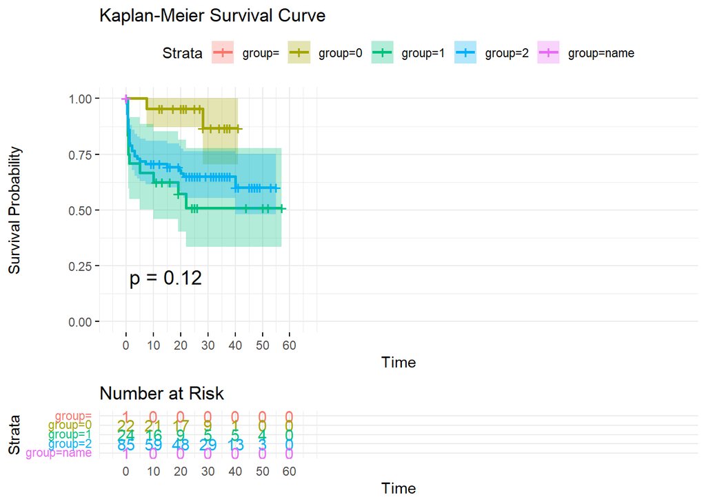

```r
ggsurvplot(survfit(surv_object ~ group, data = echocardiogram2_data),
           title = "Kaplan-Meier Survival Curve",
           xlab = "Time", ylab = "Survival Probability",
           pval = TRUE, conf.int = TRUE, risk.table = TRUE,
           xlim = c(0, 200), ylim = c(0, 1),
           risk.table.title = "Number at Risk",
           risk.table.col = "strata",
           risk.table.fontsize = 4,
           ggtheme = theme_minimal()
)
```

#### Explanation:

In the Kaplan-Meier Estimator analysis in R, the following steps were performed:

##### Loading the Survival Package:

The survival package was loaded to access functions for survival analysis.

##### Creating a Surv Object:

Using the Surv() function, a Surv object named surv_object was created, capturing the survival time and event status from the ‘echocardiogram2_data’ dataset.

##### Printing the Surv Object:

The contents of the Surv object were printed to inspect the structure and values.

##### Analyzing Data with survfit():

The survfit() function was utilized to analyze the survival data. In this case, the formula surv_object ~ 1 assumed a single group for simplicity, but adjustments can be made based on the dataset.

##### Displaying Summary of survfit Object:

A summary of the survfit object was generated using the summary() function to provide an overview of the survival analysis results.

##### Loading Additional Libraries:

Necessary libraries, including devtools, tidyverse, and survminer, were loaded to access additional functionalities.

##### Ensuring surv_object Definition:

To ensure the correct definition of ‘surv_object,’ it was redefined based on the survival time and event status columns in the dataset.

##### Generating Kaplan-Meier Curve with Stratification:

A Kaplan-Meier curve was generated using the ggsurvplot() function, with stratification by the ‘group’ variable. The plot included essential elements such as title, axis labels, p-value, confidence intervals, and a risk table.

## Visualize Survival Data

##### Ensure ‘surv_object’ is correctly defined

```r
surv_object <- Surv(time = echocardiogram2_data$survival, event = echocardiogram2_data$alive)
```

##### Generate a new Kaplan-Meier curve with stratification

```r
survfit_object <- survfit(surv_object ~ group, data = echocardiogram2_data)
```

##### Load the necessary libraries

```r
library(survival)
library(survminer)
```

##### Plot the strata using ggsurvplot()

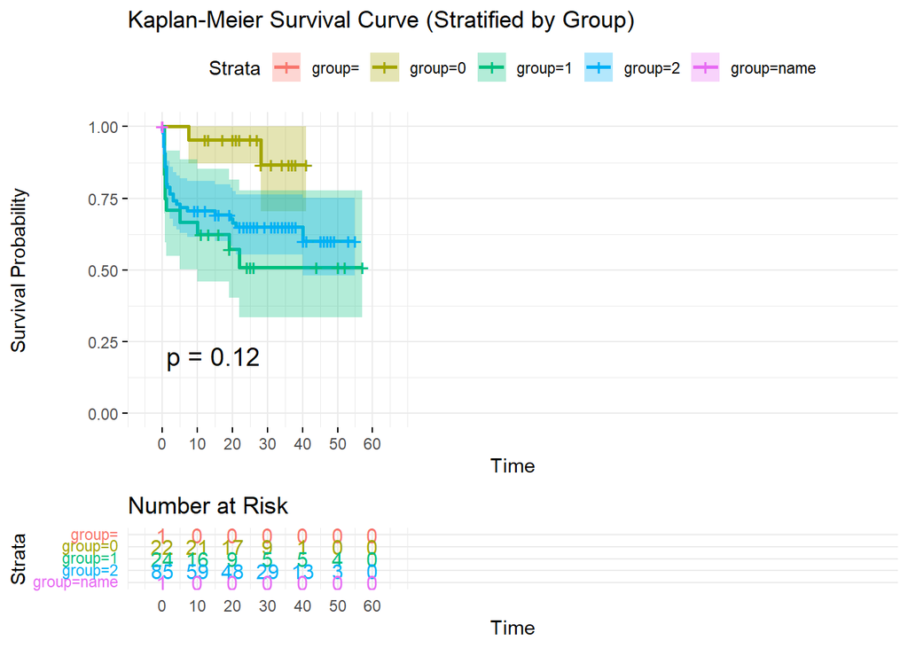

```r
ggsurvplot(survfit_object, data = echocardiogram2_data,
           title = "Kaplan-Meier Survival Curve (Stratified by Group)",
           xlab = "Time", ylab = "Survival Probability",
           pval = TRUE, conf.int = TRUE, risk.table = TRUE,
           xlim = c(0, 200), ylim = c(0, 1),
           risk.table.title = "Number at Risk",
           risk.table.col = "strata",
           risk.table.fontsize = 4,
           ggtheme = theme_minimal()
)
```

##### Plot the overall survival, stratified by ‘group’

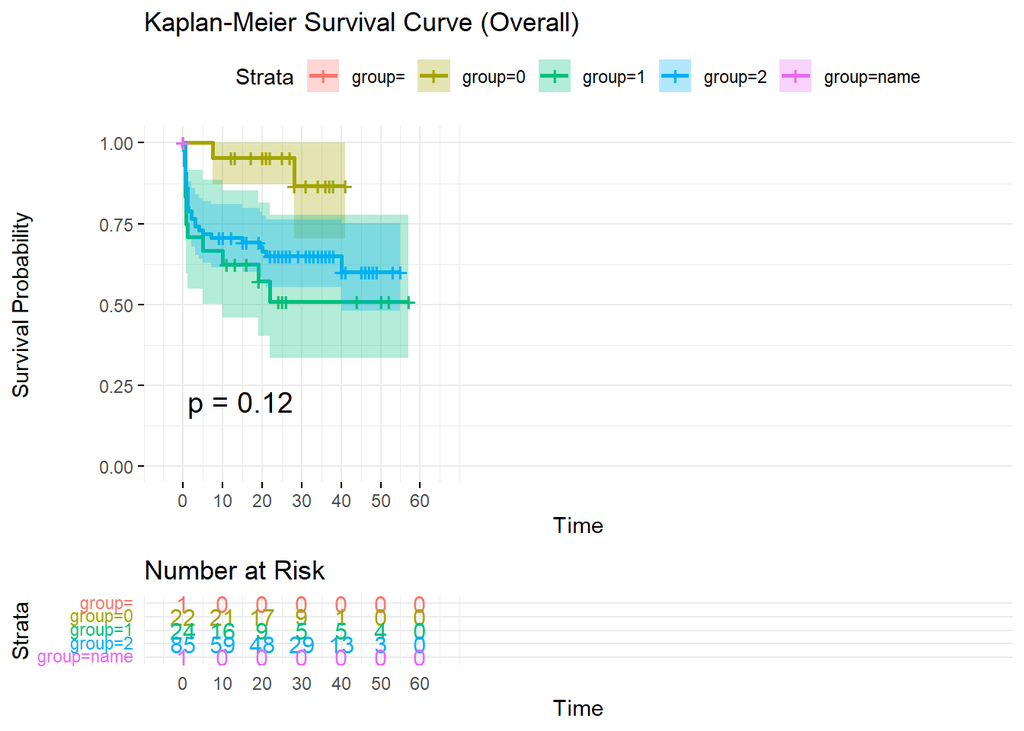

```r
ggsurvplot(survfit_object, data = echocardiogram2_data,
           title = "Kaplan-Meier Survival Curve (Overall)",
           xlab = "Time", ylab = "Survival Probability",
           pval = TRUE, conf.int = TRUE, risk.table = TRUE,
           xlim = c(0, 200), ylim = c(0, 1),
           risk.table.title = "Number at Risk",
           risk.table.col = "strata",
           risk.table.fontsize = 4,
           ggtheme = theme_minimal()
)
```

#### Explanation:

In the Visualize Survival Data analysis, the following steps were undertaken:

##### Ensuring ‘surv_object’ Definition:

The surv_object was defined using the Surv() function, capturing the survival time and event status from the ‘echocardiogram2_data’ dataset.

##### Generating Kaplan-Meier Curve with Stratification:

The survfit() function was employed to generate a Kaplan-Meier curve, stratified by the ‘group’ variable in the dataset. The resulting object, survfit_object, represented the stratified survival data.

##### Loading Necessary Libraries:

Essential libraries, including survival and survminer, were loaded to access survival analysis functions and enhance the visualization.

##### Plotting the Stratified Survival Curve:

The ggsurvplot() function was utilized to create a visually appealing Kaplan-Meier Survival Curve, stratified by the ‘group’ variable. The plot included a title, axis labels, p-value, confidence intervals, a risk table, and customized appearance settings.

## Generate K-M Curves with the Predictor

##### Ensure ‘surv_object’ is correctly defined

```r
surv_object <- Surv(time = echocardiogram2_data$survival, event = echocardiogram2_data$alive)
```

##### Generate a new Kaplan-Meier curve with stratification by ‘group’

```r
survfit_object <- survfit(surv_object ~ group, data = echocardiogram2_data)
```

##### Display the strata using summary()

```r
summary(survfit_object)
```

```
## Call: survfit(formula = surv_object ~ group, data = echocardiogram2_data)
##
##                 group=
##      time n.risk n.event survival std.err lower 95% CI upper 95% CI
##
##                 group=0
##  time n.risk n.event survival std.err lower 95% CI upper 95% CI
##   7.5     22       1    0.955  0.0444        0.871            1
##  28.0     11       1    0.868  0.0921        0.705            1
##
##                 group=1
##   time n.risk n.event survival std.err lower 95% CI upper 95% CI
##   0.50     24       4    0.833  0.0761        0.697        0.997
##   0.75     20       2    0.750  0.0884        0.595        0.945
##   1.00     18       1    0.708  0.0928        0.548        0.916
##   5.00     17       1    0.667  0.0962        0.502        0.885
##  10.00     16       1    0.625  0.0988        0.458        0.852
##  19.00     12       1    0.573  0.1034        0.402        0.816
##  22.00      9       1    0.509  0.1098        0.334        0.777
##
##                 group=2
##   time n.risk n.event survival std.err lower 95% CI upper 95% CI
##   0.00     85       1    0.988  0.0117        0.966        1.000
##   0.03     84       1    0.976  0.0164        0.945        1.000
##   0.25     83       4    0.929  0.0278        0.877        0.985
##   0.50     79       2    0.906  0.0317        0.846        0.970
##   0.75     77       4    0.859  0.0378        0.788        0.936
##   1.00     73       5    0.800  0.0434        0.719        0.890
##   1.25     68       1    0.788  0.0443        0.706        0.880
##   2.00     67       2    0.765  0.0460        0.680        0.860
##   3.00     65       2    0.741  0.0475        0.654        0.840
##   4.00     63       1    0.729  0.0482        0.641        0.830
##   5.00     62       1    0.718  0.0488        0.628        0.820
##   7.00     61       1    0.706  0.0494        0.615        0.810
##  15.00     54       1    0.693  0.0502        0.601        0.799
##  19.50     49       1    0.679  0.0511        0.586        0.787
##  20.00     48       1    0.665  0.0520        0.570        0.775
##  21.00     47       1    0.650  0.0528        0.555        0.762
##  40.00     13       1    0.600  0.0684        0.480        0.751
##
##                 group=name
##      time n.risk n.event survival std.err lower 95% CI upper 95% CI
```

##### Plot the strata using ggsurvplot()

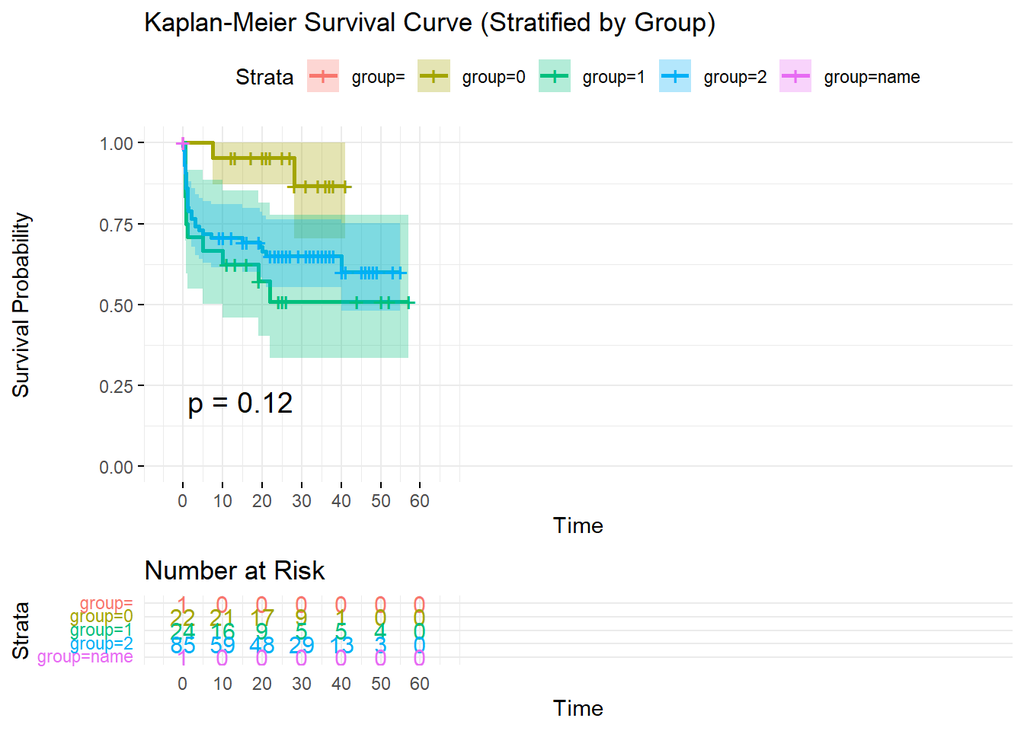

```r
ggsurvplot(survfit_object, data = echocardiogram2_data,
           title = "Kaplan-Meier Survival Curve (Stratified by Group)",
           xlab = "Time", ylab = "Survival Probability",
           pval = TRUE, conf.int = TRUE, risk.table = TRUE,
           xlim = c(0, 200), ylim = c(0, 1),
           risk.table.title = "Number at Risk",
           risk.table.col = "strata",
           risk.table.fontsize = 4,
           ggtheme = theme_minimal()
)
```

##### Plot the overall survival, stratified by ‘group’

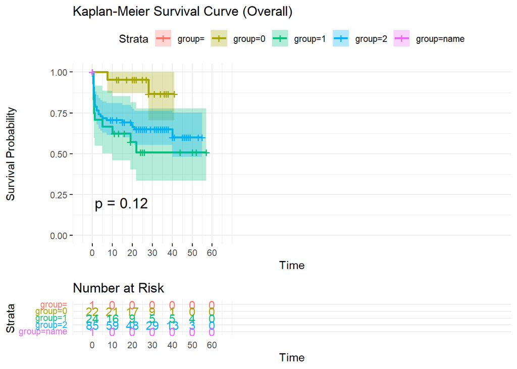

```r
ggsurvplot(survfit_object, data = echocardiogram2_data,
           title = "Kaplan-Meier Survival Curve (Overall)",
           xlab = "Time", ylab = "Survival Probability",
           pval = TRUE, conf.int = TRUE, risk.table = TRUE,
           xlim = c(0, 200), ylim = c(0, 1),
           risk.table.title = "Number at Risk",
           risk.table.col = "strata",
           risk.table.fontsize = 4,
           ggtheme = theme_minimal()
)
```

#### Explanation

In the process of generating Kaplan-Meier (K-M) curves with the predictor ‘group’ in the echocardiogram2 dataset, I executed the following steps:

##### Defining Survival Object:

I ensured the correct definition of the survival object (surv_object), incorporating information on survival time and events from the dataset. This object serves as the basis for subsequent survival analyses.

##### Generating K-M Curve with Stratification:

Using the survfit function, I created a Kaplan-Meier curve (survfit_object) with stratification by the ‘group’ variable. This step allows a detailed examination of survival probabilities specific to each group.

##### Displaying Strata Information:

I utilized the summary() function to display a summary of the strata, providing key statistics and information about each group’s survival curve.

##### Plotting Strata with ggsurvplot:

Employing the ggsurvplot() function, I generated a visually informative plot illustrating the Kaplan-Meier survival curve stratified by ‘group’. The plot includes p-values, confidence intervals, and a risk table for enhanced interpretation.

## Perform Log-Rank Analysis

##### Assuming we have ‘surv_object’ and ‘echocardiogram2_data’ correctly defined

##### Ensure ‘surv_object’ is correctly defined

```r
surv_object <- Surv(time = echocardiogram2_data$survival, event = echocardiogram2_data$alive)
```

##### Fit Kaplan-Meier survival curves

```r
survfit_object <- survfit(surv_object ~ group, data = echocardiogram2_data)
```

##### Perform log-rank test

```r
log_rank_test <- survdiff(surv_object ~ group, data = echocardiogram2_data)
print(log_rank_test)
```

```
## Call:
## survdiff(formula = surv_object ~ group, data = echocardiogram2_data)
##
##             N Observed Expected (O-E)^2/E (O-E)^2/V
## group=      1        0  0.00752   0.00752   0.00758
## group=0    22        2  8.31692   4.79786   6.10790
## group=1    24       11  7.19027   2.01857   2.48996
## group=2    85       30 27.47778   0.23152   0.65592
## group=name  1        0  0.00752   0.00752   0.00758
##
##  Chisq= 7.3  on 4 degrees of freedom, p= 0.1
```

##### Plot Kaplan-Meier curve with log-rank test

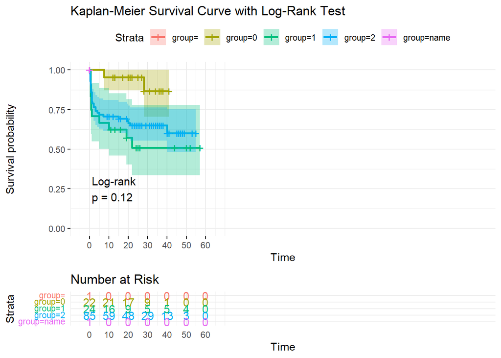

```r
ggsurvplot(survfit_object, data = echocardiogram2_data,
           title = "Kaplan-Meier Survival Curve with Log-Rank Test",
           pval = TRUE,              # Display p-value for survival curves
           conf.int = TRUE,          # Display confidence intervals
           risk.table = TRUE,        # Display risk table
           xlim = c(0, 200),         # Set x-axis limits
           ylim = c(0, 1),           # Set y-axis limits
           risk.table.title = "Number at Risk",
           risk.table.col = "strata",
           risk.table.fontsize = 4,
           ggtheme = theme_minimal(),  # Use a minimal theme, adjust as needed
           surv.median.line = "hv",   # Add median survival line
           pval.method = TRUE,         # Use log-rank test for p-value
           pval.size = 4               # Adjust p-value font size
)
```

##### Plot Kaplan-Meier curve without median line

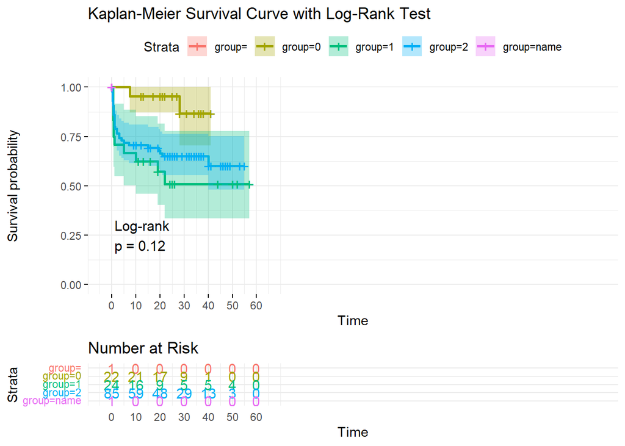

```r
ggsurvplot(survfit_object, data = echocardiogram2_data,
           title = "Kaplan-Meier Survival Curve with Log-Rank Test",
           pval = TRUE,
           conf.int = TRUE,
           risk.table = TRUE,
           xlim = c(0, 200),
           ylim = c(0, 1),
           risk.table.title = "Number at Risk",
           risk.table.col = "strata",
           risk.table.fontsize = 4,
           ggtheme = theme_minimal(),
           pval.method = TRUE,
           pval.size = 4
)
```

#### Explanation:

##### 1. Defining Survival Object:

I started by creating a survival object, encapsulating the survival time and event details from the dataset. This step lays the foundation for subsequent survival analyses.

##### 2.Fitting Kaplan-Meier Survival Curves:

Utilizing the survfit function, I generated Kaplan-Meier survival curves for distinct groups. This visual representation illustrates how survival probabilities vary over time, specifically when stratified by the ‘group’ variable.

##### 3.Performing Log-Rank Test:

I conducted the log-rank test (log_rank_test) to statistically assess differences in survival curves between different groups. This test is crucial for determining whether there are significant variations in survival outcomes.

##### 4. Plotting Kaplan-Meier Curve with Log-Rank Test:

The resulting Kaplan-Meier curve plot incorporated the log-rank test results, providing a comprehensive visualization of survival probabilities. The plot includes confidence intervals and a risk table for additional insights.

##### 5. Plotting Kaplan-Meier Curve without Median Line:

Additionally, I created an alternative Kaplan-Meier curve plot without the median survival line. This variation allows a focused view of survival curves without the distraction of median information.